# Final_Report.rmd

```r
table(NHIS_clean$HISPALLP_A)
```

```
##
##     1     2     3     4     5     6     7
##  3533 17617  2645  1564   153   196   329
```

```r
table(NHIS_clean$EDUCP_recode)
```

```
##
## College Graduate or Better       High School Graduate
##                      10358                       5765
##      Less than High School     Some College Education
##                       2676                       7238
```

```r
table(NHIS_clean$PHSTAT_A)
```

```
##
##    1    2    3    4    5
## 6065 9185 7287 2717  783
```

```r
table(NHIS_clean$LSATIS4R_A)
```

```
##
##     1     2     3     4
## 12458 12266  1025   288
```

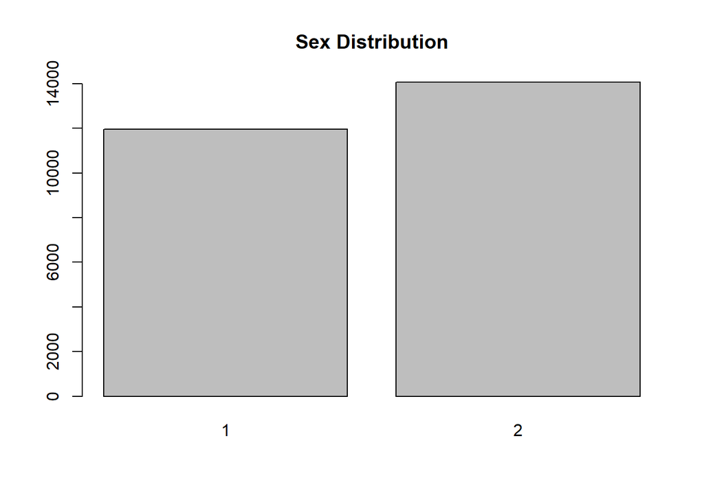

```r
#Bar Plots
barplot(table(NHIS_clean$SEX_A), main="Sex Distribution")
```

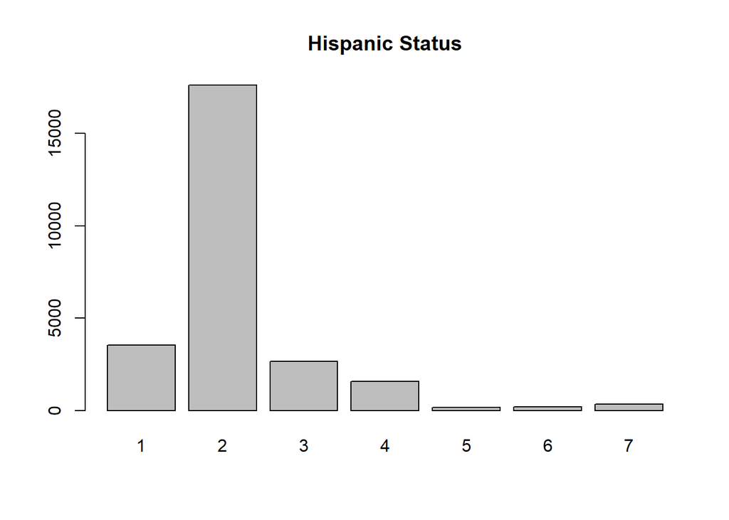

```r
barplot(table(NHIS_clean$HISPALLP_A), main="Hispanic Status")
```

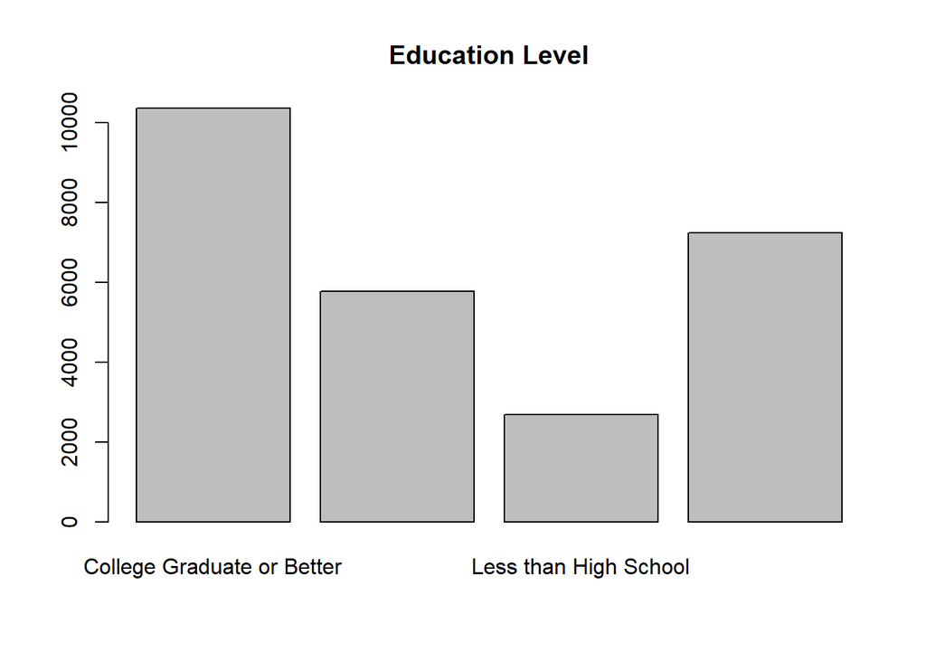

```r
barplot(table(NHIS_clean$EDUCP_recode), main="Education Level")
```

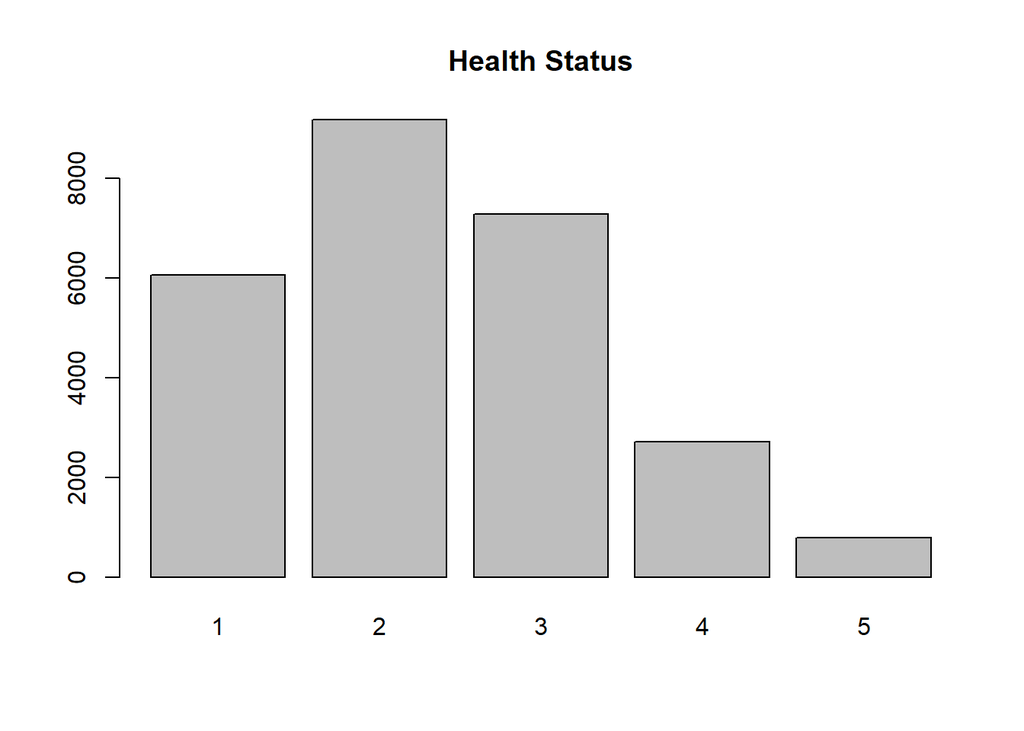

```r
barplot(table(NHIS_clean$PHSTAT_A), main="Health Status")
```

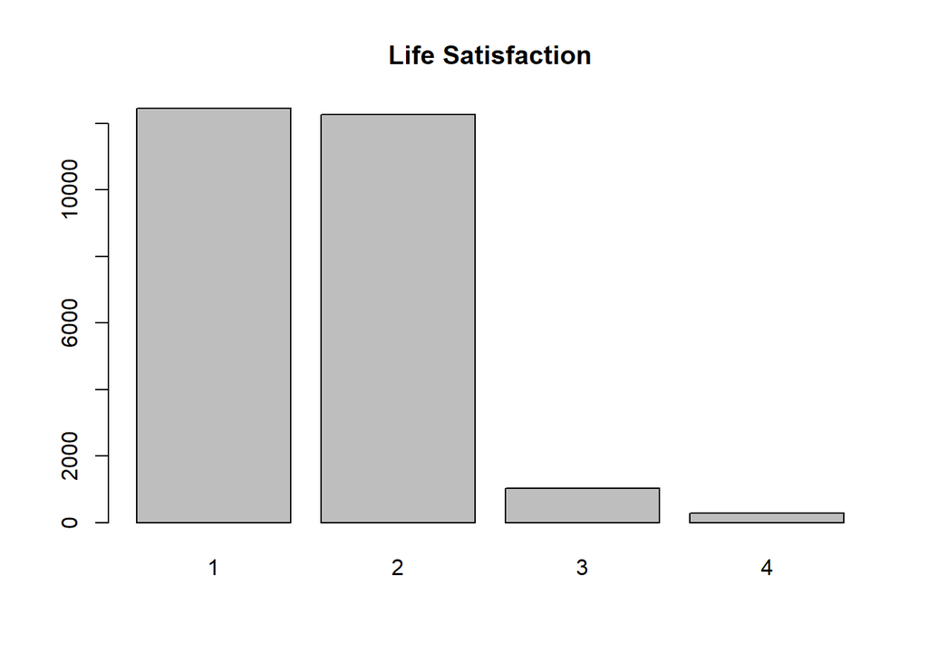

```r
barplot(table(NHIS_clean$LSATIS4R_A), main="Life Satisfaction")
```

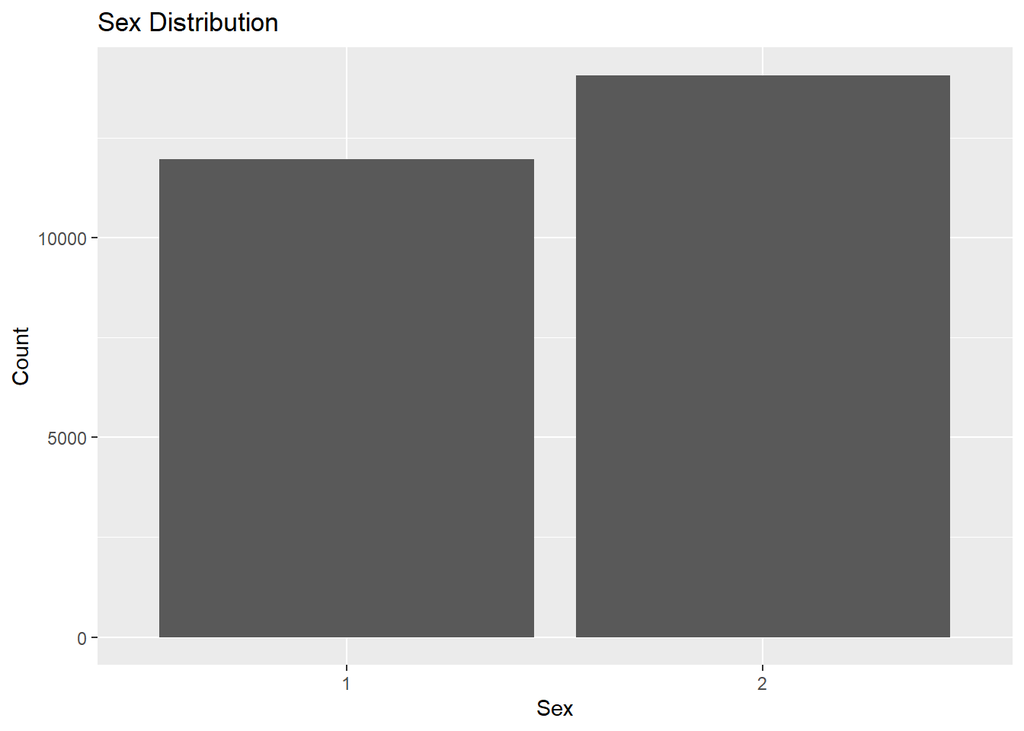

```r
ggplot(NHIS_clean, aes(x = factor(SEX_A))) +
  geom_bar() +
  labs(title="Sex Distribution", x="Sex", y="Count")
```

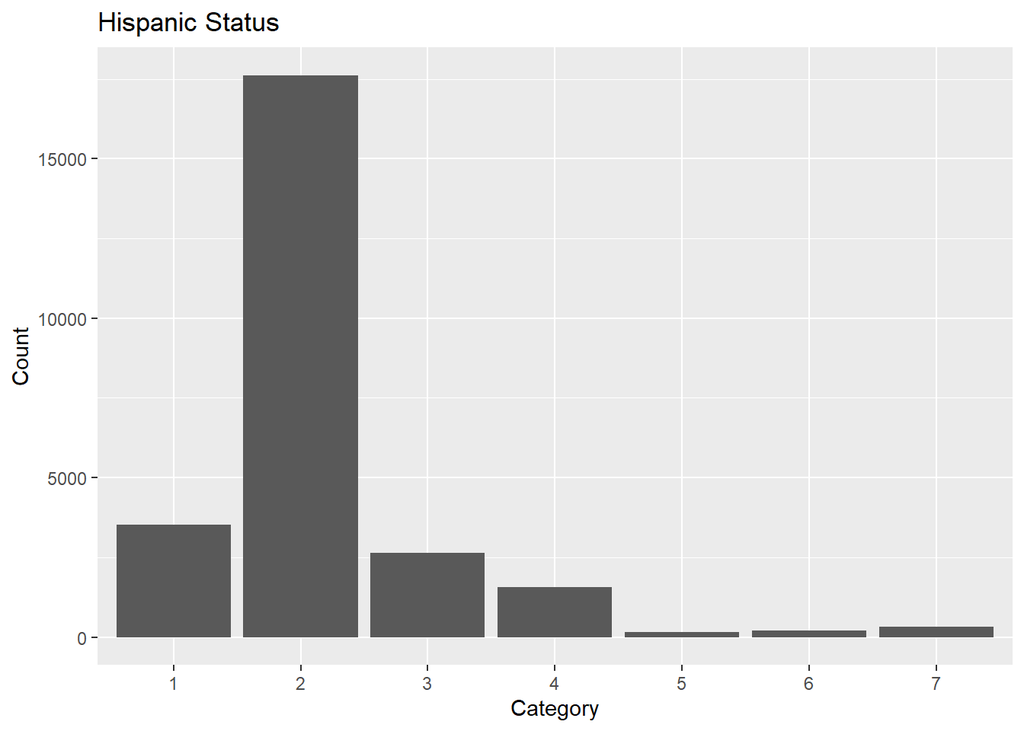

```r
ggplot(NHIS_clean, aes(x = factor(HISPALLP_A))) +
  geom_bar() +
  labs(title="Hispanic Status", x="Category", y="Count")
```

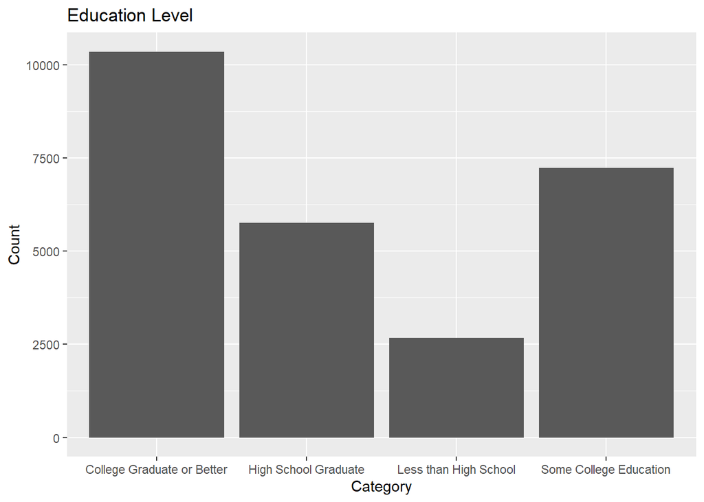

```r
ggplot(NHIS_clean, aes(x = factor(EDUCP_recode))) +
  geom_bar() +
  labs(title="Education Level", x="Category", y="Count")
```

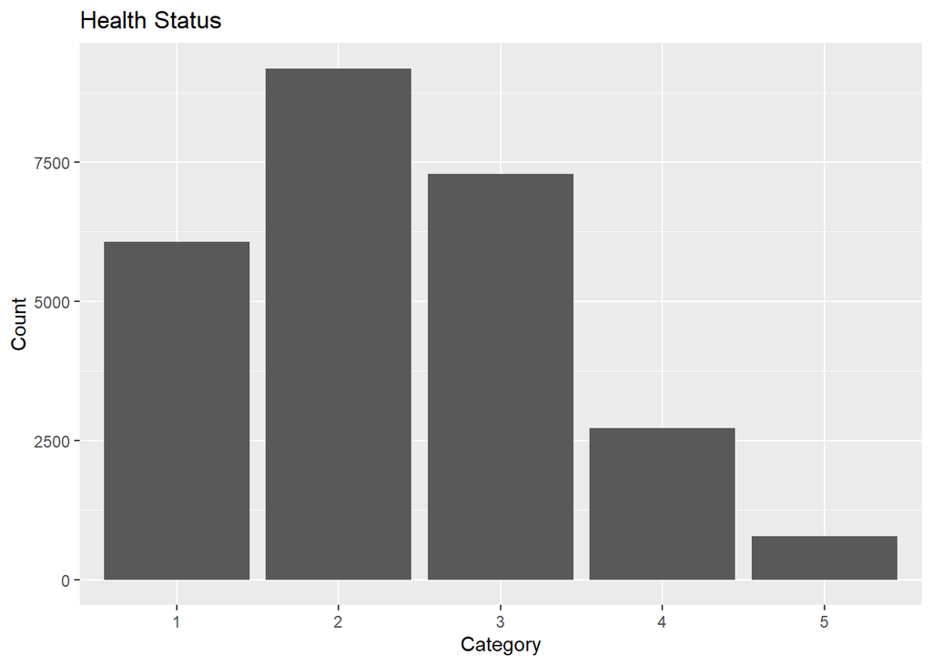

```r
ggplot(NHIS_clean, aes(x = factor(PHSTAT_A))) +
  geom_bar() +
  labs(title="Health Status", x="Category", y="Count")
```

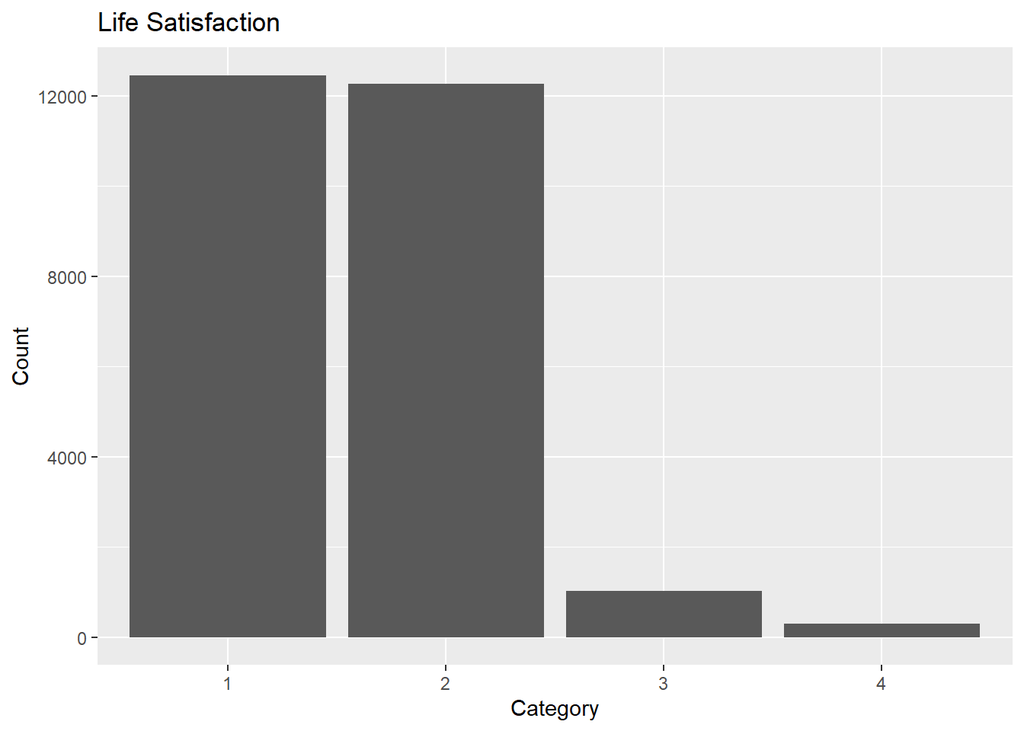

```r
ggplot(NHIS_clean, aes(x = factor(LSATIS4R_A))) +
  geom_bar() +
  labs(title="Life Satisfaction", x="Category", y="Count")
```

```r
#Qualitative Variables
#Frequency tables
table(NHIS_clean$SEX_A)
```

```
##
##     1     2
## 11967 14070
```

```r
table(NHIS_clean$HISPALLP_A)
```

```
##
##     1     2     3     4     5     6     7
##  3533 17617  2645  1564   153   196   329
```

```r
table(NHIS_clean$EDUCP_recode)
```

```
##
## College Graduate or Better       High School Graduate
##                      10358                       5765
##      Less than High School     Some College Education
##                       2676                       7238
```

```r
table(NHIS_clean$PHSTAT_A)
```

```
##
##    1    2    3    4    5
## 6065 9185 7287 2717  783
```

```r
table(NHIS_clean$LSATIS4R_A)
```

```
##
##     1     2     3     4
## 12458 12266  1025   288
```

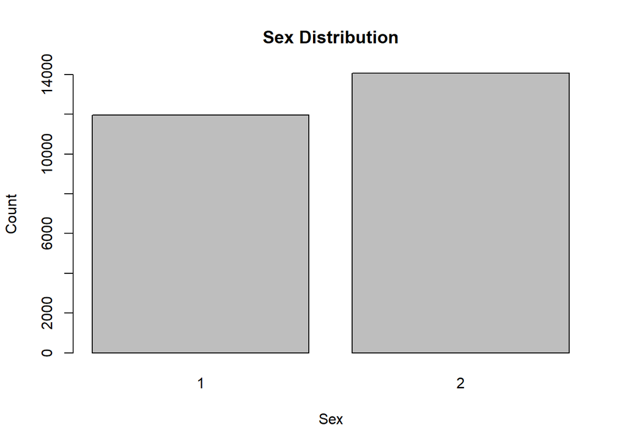

```r
#Bar Plots
barplot(table(NHIS_clean$SEX_A),
        main = "Sex Distribution",
        xlab = "Sex", ylab = "Count")
```

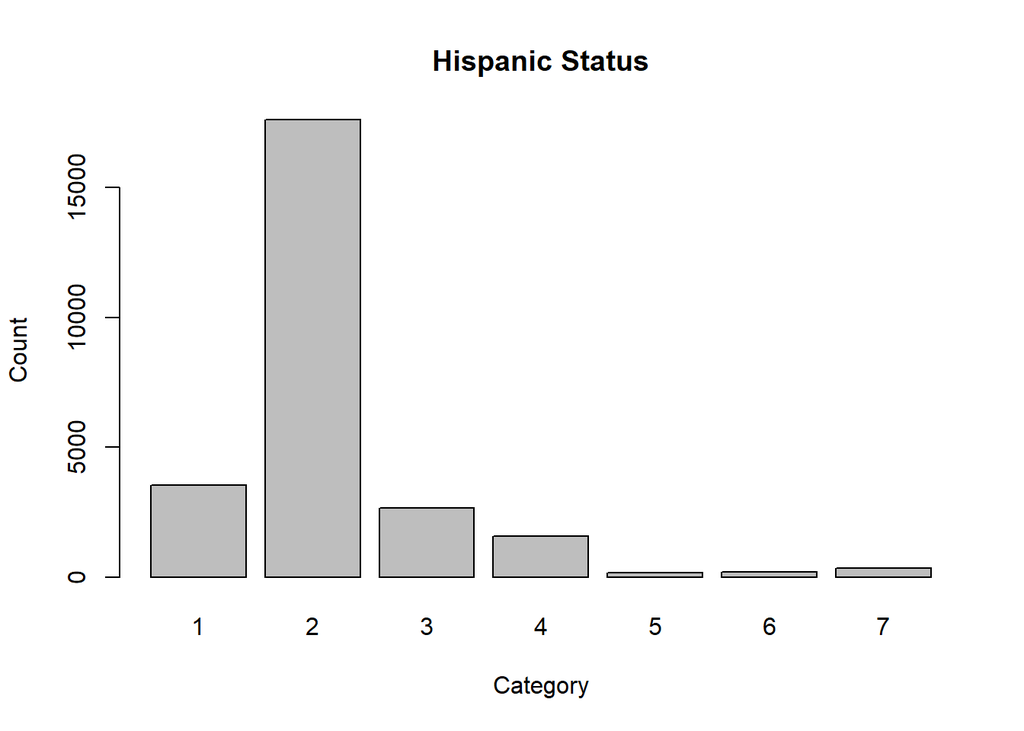

```r
barplot(table(NHIS_clean$HISPALLP_A),
        main = "Hispanic Status",
        xlab = "Category", ylab = "Count")
```

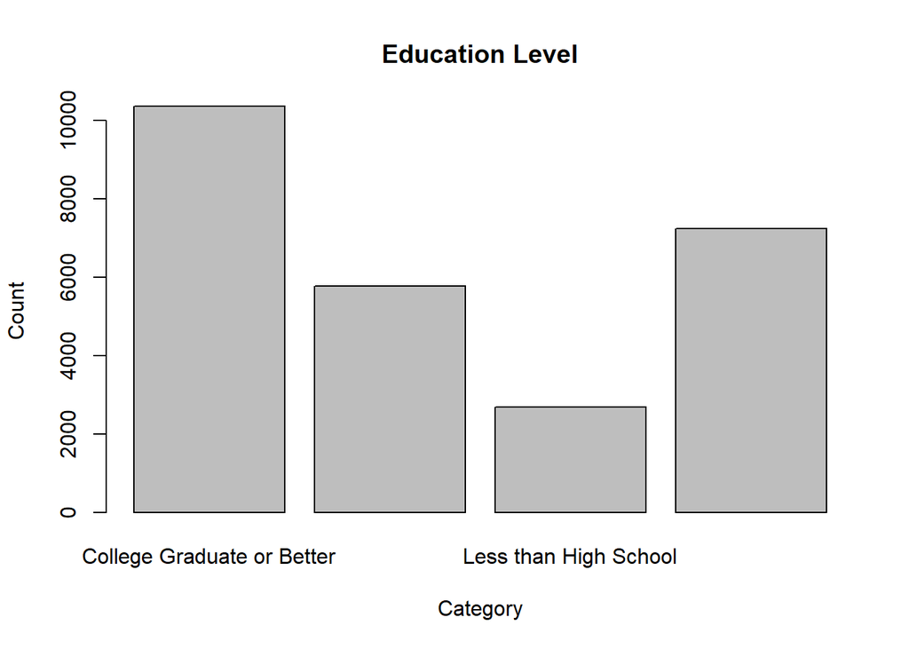

```r
barplot(table(NHIS_clean$EDUCP_recode),
        main = "Education Level",
        xlab = "Category", ylab = "Count")
```

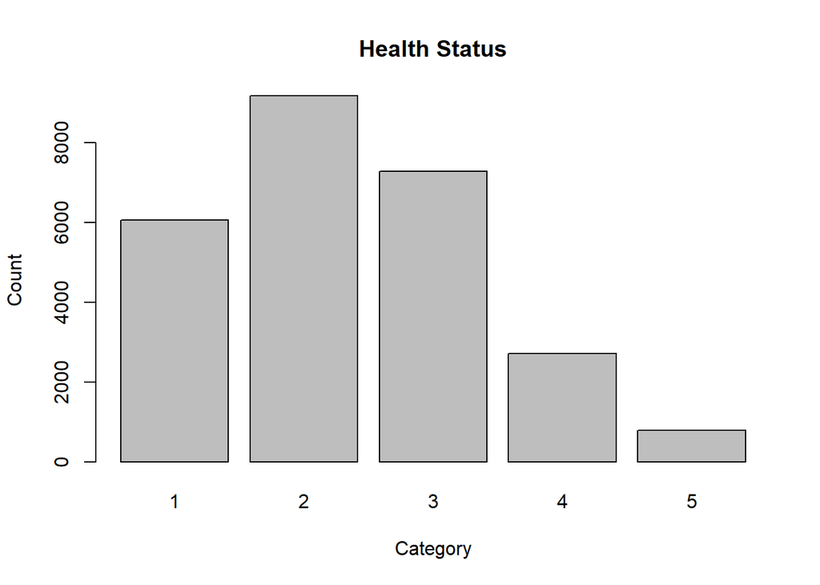

```r
barplot(table(NHIS_clean$PHSTAT_A),
        main = "Health Status",
        xlab = "Category", ylab = "Count")
```

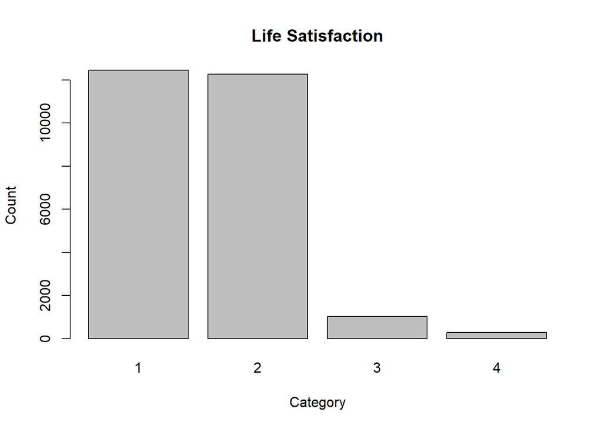

```r
barplot(table(NHIS_clean$LSATIS4R_A),
        main = "Life Satisfaction",
        xlab = "Category", ylab = "Count")
```

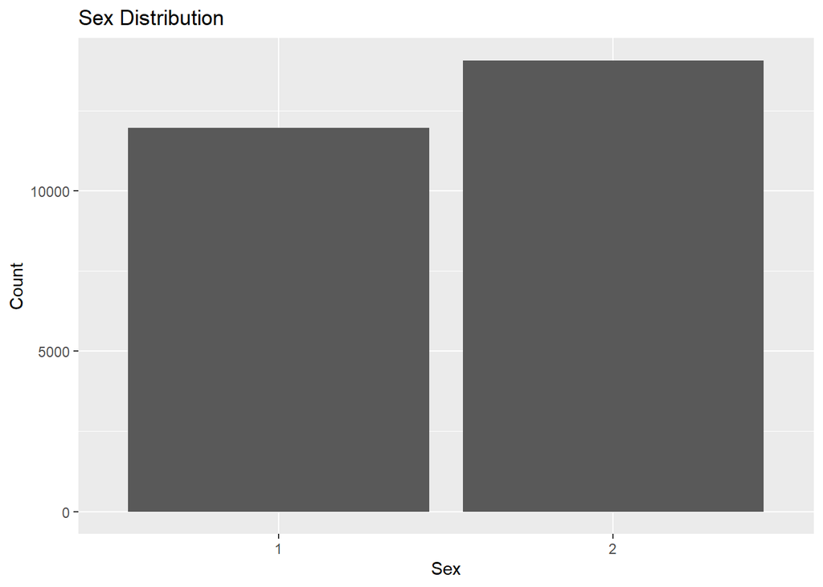

```r
ggplot(NHIS_clean, aes(x = factor(SEX_A))) +
  geom_bar() +
  labs(title = "Sex Distribution", x = "Sex", y = "Count")
```

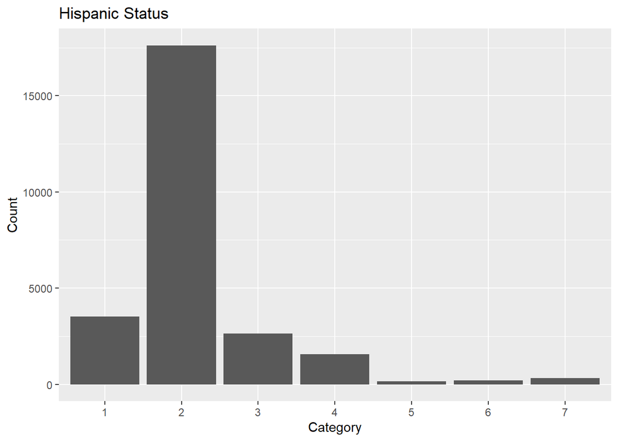

```r
ggplot(NHIS_clean, aes(x = factor(HISPALLP_A))) +
  geom_bar() +
  labs(title = "Hispanic Status", x = "Category", y = "Count")
```

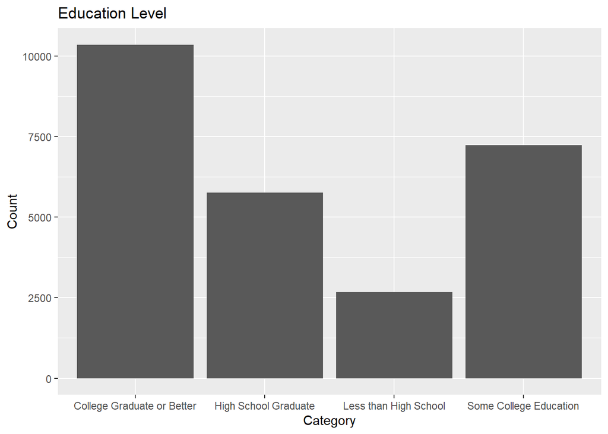

```r
ggplot(NHIS_clean, aes(x = factor(EDUCP_recode))) +
  geom_bar() +
  labs(title = "Education Level", x = "Category", y = "Count")
```

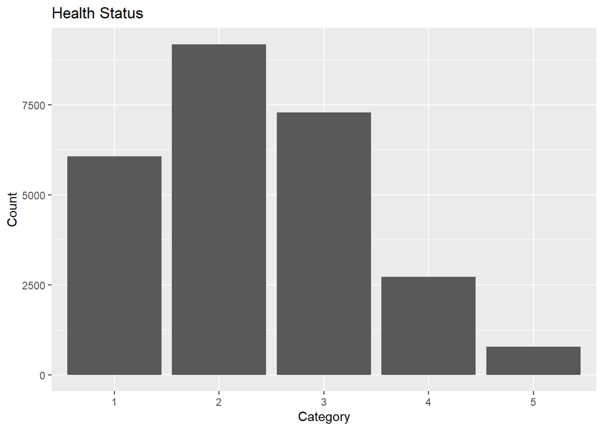

```r
ggplot(NHIS_clean, aes(x = factor(PHSTAT_A))) +
  geom_bar() +
  labs(title = "Health Status", x = "Category", y = "Count")
```

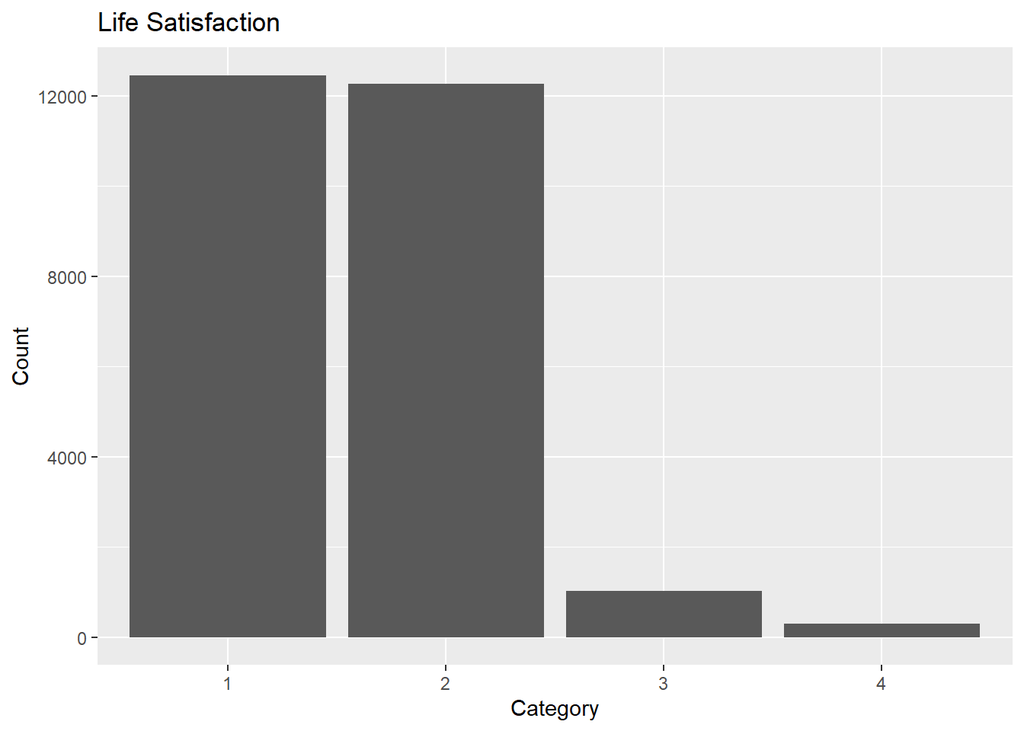

```r
ggplot(NHIS_clean, aes(x = factor(LSATIS4R_A))) +
  geom_bar() +
  labs(title = "Life Satisfaction", x = "Category", y = "Count")
```

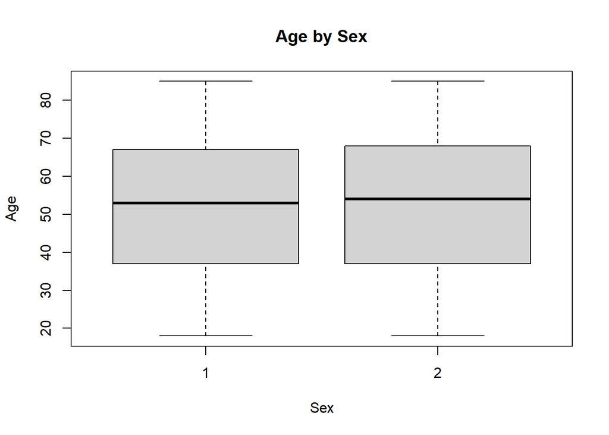

```r
#04_bivariate_analysis.R

library(tidyverse)
NHIS_clean <- read.csv("Data/NHIS_clean.csv")

#Quantitative vs. Qualitative:
boxplot(AGEP_A ~ SEX_A, #create boxplot for varbiables
        data = NHIS_clean,
        main = "Age by Sex", # title
        xlab = "Sex", # x axis label
        ylab = "Age") #y axis label
```

Key

Male: 1

Female: 2

Age distributions are similar across both sex groups, with comparable medians and spread, suggesting no significant difference in age by sex.

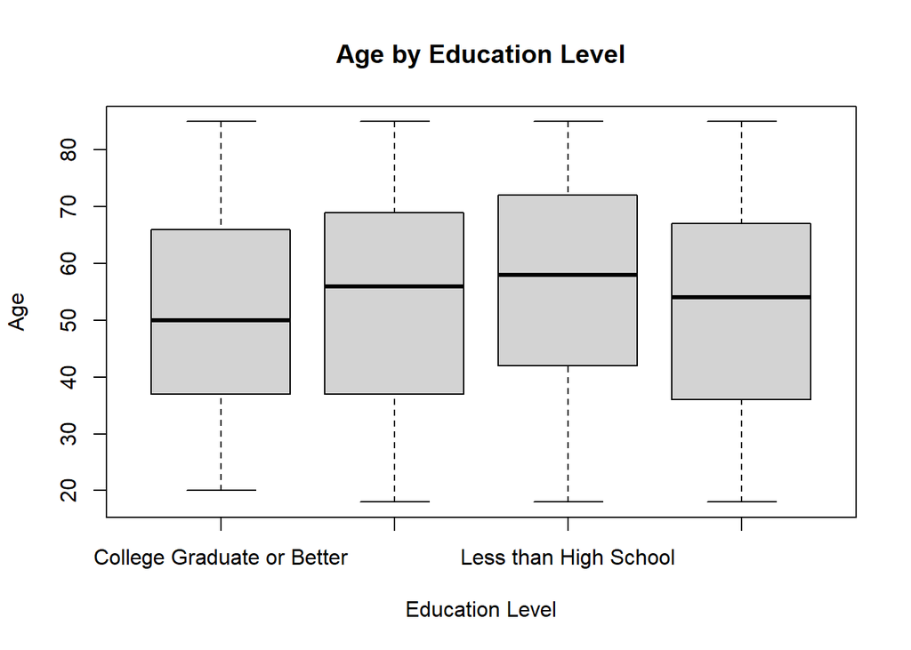

```r
boxplot(AGEP_A ~ EDUCP_recode, #create boxplot for variables
        data = NHIS_clean,
        main = "Age by Education Level", #title
        xlab = "Education Level", # x axis label
        ylab = "Age") #y axis label
```

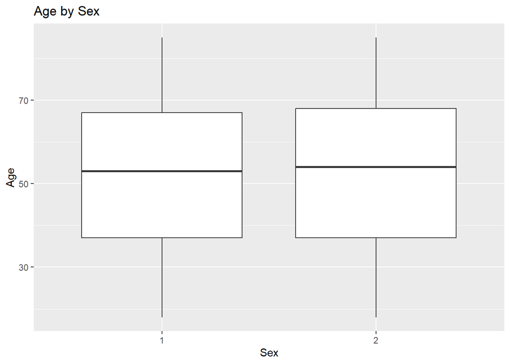

```r
ggplot(NHIS_clean, aes(x = factor(SEX_A), y = AGEP_A)) + # create ggplot for varibles
  geom_boxplot() + # assign boxplot
  labs(title = "Age by Sex", #title
       x = "Sex", # x axis variable
       y = "Age") # y axis variable
```

Key

Male: 1 Female: 2

The boxplot shows that age between the two sex groups is pretty similar overall. Both groups have around the same median age, maybe slightly higher for one group but not by much.

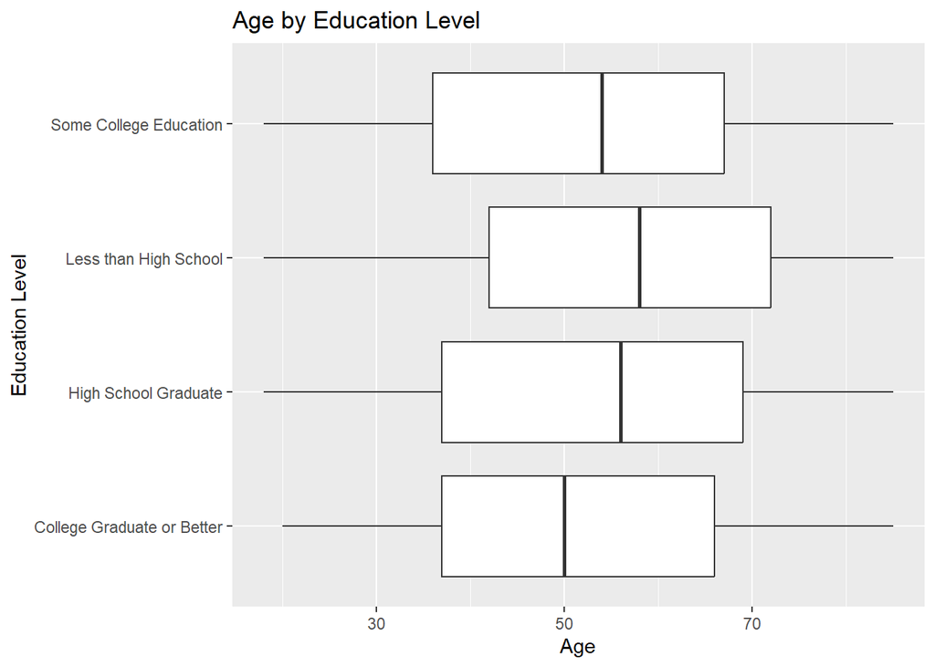

```r
ggplot(NHIS_clean, aes(x = factor(EDUCP_recode), y = AGEP_A)) + #create ggplot for varaible
  geom_boxplot() + # assign boxplot to ggplot
  labs(title = "Age by Education Level", #create title
       x = "Education Level", # x axis
       y = "Age") + coord_flip() # y axis
```

The boxplot shows that age is pretty similar across all education levels. There are some small differences, like slightly higher median ages in certain groups, but overall the distributions overlap a lot. This suggests education level doesn’t really change age that much in this dataset.

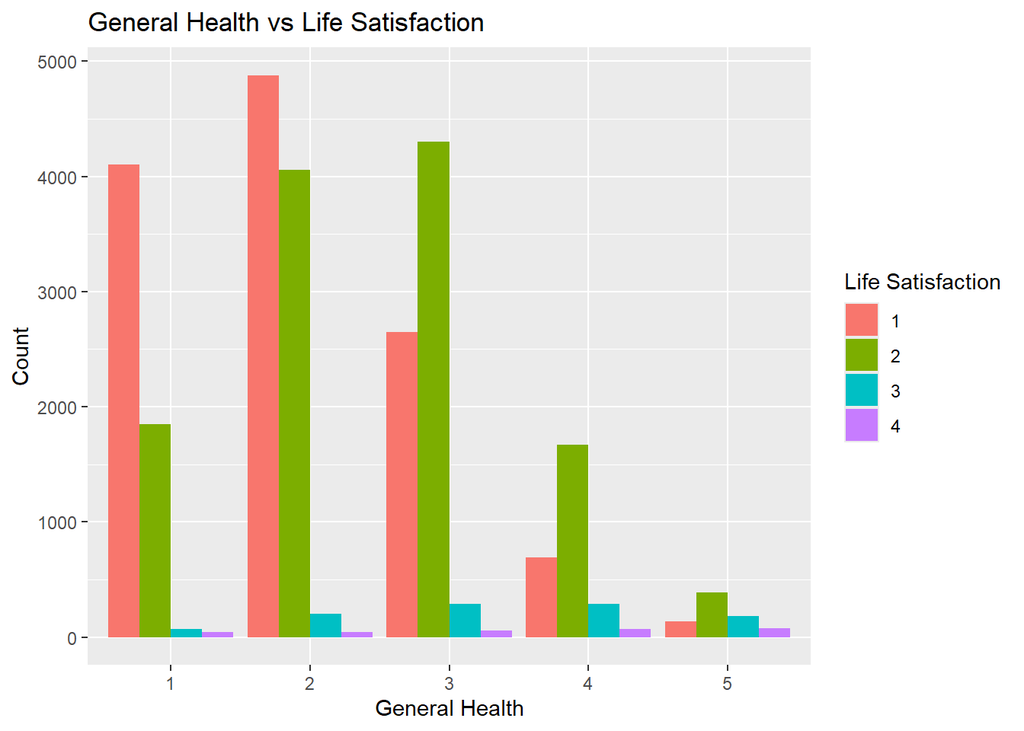

```r
#Qualitative vs. Qualitative:
ggplot(NHIS_clean, # create ggplot for variables
       aes(x = factor(PHSTAT_A), fill = factor(LSATIS4R_A))) +
  geom_bar(position = "dodge") + # assign as a bar graph
  labs(title = "General Health vs Life Satisfaction", #title
       x = "General Health", #x axis
       y = "Count", # y axis
       fill = "Life Satisfaction") # Key on the side
```

Key

1: Excellent 2: Very good 3: Good 4: Fair 5: Poor

The chart shows a clear relationship between general health and life satisfaction. People who report excellent or very good health (1–2) tend to have higher life satisfaction, while those with fair or poor health (4–5) more often report lower satisfaction. There’s still some overlap, but overall better health is linked to better life satisfaction.

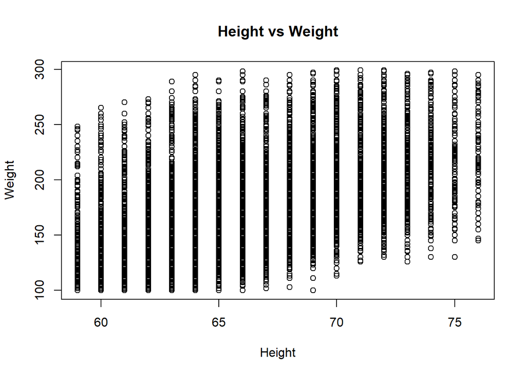

```r
#Quantitative vs. Quantitative:
plot(NHIS_clean$HEIGHTTC_A, # simple plot graph between two variables
     NHIS_clean$WEIGHTLBTC_A,
     main = "Height vs Weight", #title
     xlab = "Height", # x axis
     ylab = "Weight") # y axis
```

The scatterplot shows a positive relationship between height and weight. As height increases, weight also tends to increase, although there is a lot of variation at each height. The points are pretty spread out, so it’s not a perfect relationship but the general trend is still clear.

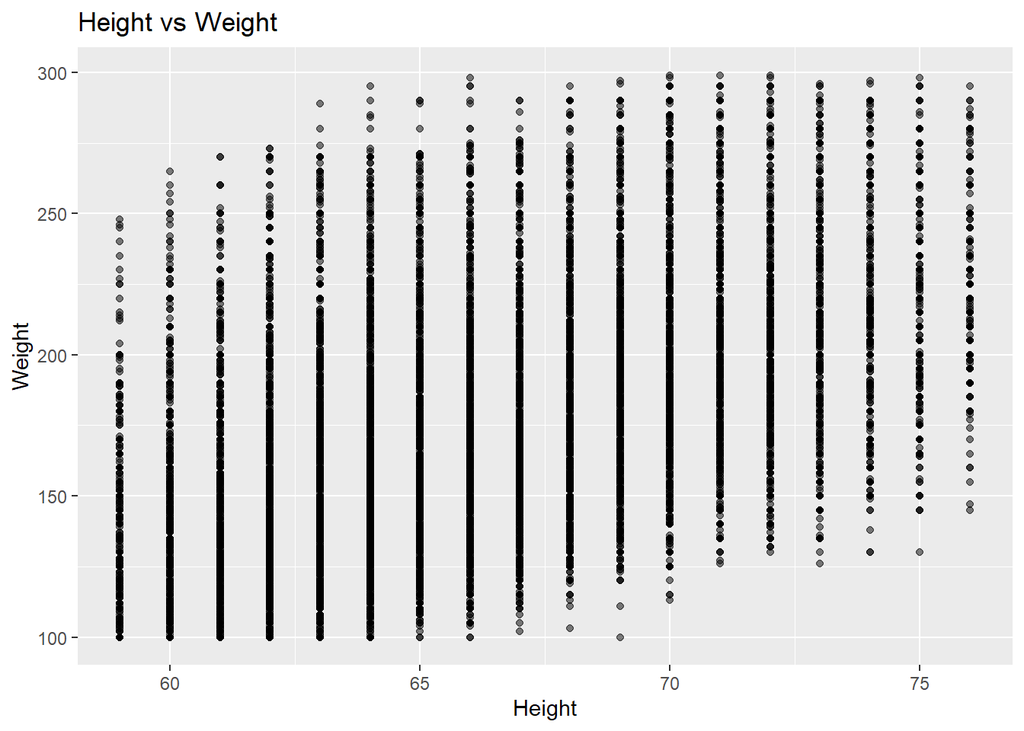

```r
ggplot(NHIS_clean, aes(x = HEIGHTTC_A, y = WEIGHTLBTC_A)) + #ggplot of two variables
  geom_point(alpha = 0.5) + # assign as a scatter plot point graph
  labs(title = "Height vs Weight", #title
       x = "Height", #x axis
       y = "Weight") # y axis
```

```r
cor(NHIS_clean$HEIGHTTC_A,
    NHIS_clean$WEIGHTLBTC_A,
    use = "complete.obs")
```

```
## [1] 0.5023037
```

There is a moderate positive relationship between height and weight, indicating that as height increases, weight also tends to increase. The correlation coefficient (r = 0.50) suggests a moderate linear association between the two variables.

# Day 4: Multivariate Analysis & Report Drafting

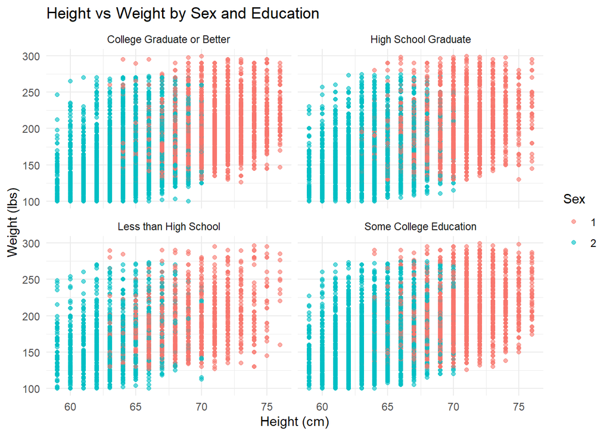

```r
# Select variables and remove missing values
multi_data <- NHIS_clean %>%
  select(HEIGHTTC_A, WEIGHTLBTC_A, SEX_A, EDUCP_recode, PHSTAT_A, AGEP_A) %>%
  na.omit()

# Convert variables to factors
multi_data$SEX_A <- as.factor(multi_data$SEX_A)
multi_data$EDUCP_recode <- as.factor(multi_data$EDUCP_recode)
multi_data$PHSTAT_A <- as.factor(multi_data$PHSTAT_A)

# Scatterolot of height vs weight, colored by sex and faceted by education
ggplot(multi_data, aes(x = HEIGHTTC_A, y = WEIGHTLBTC_A, color = SEX_A)) +
  geom_point(alpha = 0.6) + # points with transparency
  facet_wrap(~ EDUCP_recode) + #split by education level
  labs(
    title = "Height vs Weight by Sex and Education",
    x = "Height (cm)",
    y = "Weight (lbs)",
    color = "Sex"
  ) +
  theme_minimal() # clean theme
```

The scatterplots show a positive relationship between height and weight across all education levels. This pattern looks pretty consistent regardless of education, and both sex groups follow a similar trend. There are some small differences, but overall the relationship between height and weight stays about the same.